# Clustering Protein consumption data

We will analyse the *Protein* dataset. The dataset contains information about protein consumption (divided into various subgroups) for 25 European countries in 1973. Our goal will be to cluster countries together based on their protein consumption.

### Prepare the data

Begin with the data:

```r
head(df)
```

```
## Source: local data frame [6 x 10]
##
##          Country RedMeat WhiteMeat  Eggs  Milk  Fish Cereals Starch  Nuts
##            (chr)   (dbl)     (dbl) (dbl) (dbl) (dbl)   (dbl)  (dbl) (dbl)
## 1        Albania    10.1       1.4   0.5   8.9   0.2    42.3    0.6   5.5
## 2        Austria     8.9      14.0   4.3  19.9   2.1    28.0    3.6   1.3
## 3        Belgium    13.5       9.3   4.1  17.5   4.5    26.6    5.7   2.1
## 4       Bulgaria     7.8       6.0   1.6   8.3   1.2    56.7    1.1   3.7
## 5 Czechoslovakia     9.7      11.4   2.8  12.5   2.0    34.3    5.0   1.1
## 6        Denmark    10.6      10.8   3.7  25.0   9.9    21.9    4.8   0.7
## Variables not shown: Fr&Veg (dbl)
```

Scale the data:

```r
df_scaled = data.frame( scale(dplyr::select(df, -Country))   )
rownames(df_scaled) = unlist(dplyr::select(df, Country))
df_scaled[1:3, 1:3]
```

```
##            RedMeat  WhiteMeat      Eggs
## Albania  0.0812649 -1.7584889 -2.179639
## Austria -0.2772567  1.6523731  1.220454
## Belgium  1.0970762  0.3800675  1.041502
```

### Use distance-based clustering

create a distance matrix from the data:

```r
dist_obj = dist(df_scaled, method="euclidean")
```

Create a convenience function to print clusters:

```r
print_clusters = function(labels, k)
{
  for(i in 1:k)
  {
    print(paste("cluster", i))
    print(df[labels == i, c("Country", "RedMeat", "Fish", "Fr&Veg")])
  }
}
```

Use *hclust()* to cluster the data:

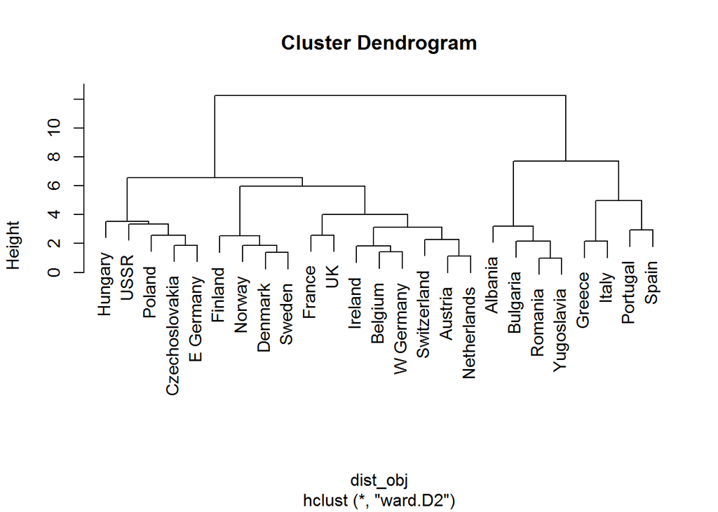

```r
cluster_obj = cutree(  hclust(dist_obj, method = "ward.D2" )  , k=4  )

plot(hclust(dist_obj, method = "ward.D2" ))
```

Print the clusters:

```r
print_clusters(cluster_obj, 3)
```

```
## [1] "cluster 1"
## Source: local data frame [4 x 4]
##
##      Country RedMeat  Fish Fr&Veg
##        (chr)   (dbl) (dbl)  (dbl)
## 1    Albania    10.1   0.2    1.7
## 2   Bulgaria     7.8   1.2    4.2
## 3    Romania     6.2   1.0    2.8
## 4 Yugoslavia     4.4   0.6    3.2
## [1] "cluster 2"
## Source: local data frame [12 x 4]
##
##        Country RedMeat  Fish Fr&Veg
##          (chr)   (dbl) (dbl)  (dbl)
## 1      Austria     8.9   2.1    4.3
## 2      Belgium    13.5   4.5    4.0
## 3      Denmark    10.6   9.9    2.4
## 4      Finland     9.5   5.8    1.4
## 5       France    18.0   5.7    6.5
## 6      Ireland    13.9   2.2    2.9
## 7  Netherlands     9.5   2.5    3.7
## 8       Norway     9.4   9.7    2.7
## 9       Sweden     9.9   7.5    2.0
## 10 Switzerland    13.1   2.3    4.9
## 11          UK    17.4   4.3    3.3
## 12   W Germany    11.4   3.4    3.8
## [1] "cluster 3"
## Source: local data frame [5 x 4]
##
##          Country RedMeat  Fish Fr&Veg
##            (chr)   (dbl) (dbl)  (dbl)
## 1 Czechoslovakia     9.7   2.0    4.0
## 2      E Germany     8.4   5.4    3.6
## 3        Hungary     5.3   0.3    4.2
## 4         Poland     6.9   3.0    6.6
## 5           USSR     9.3   3.0    2.9
```

plot the clusters:

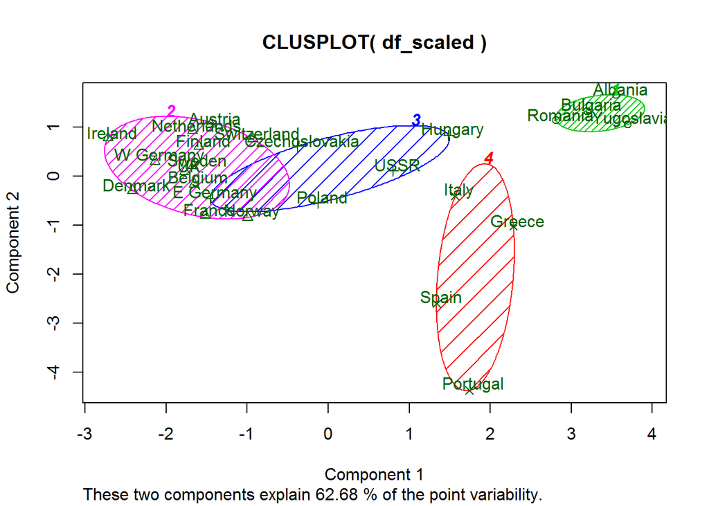

```r
clusplot(df_scaled, cluster_obj, color=TRUE, shade=TRUE, labels=2, lines=0  )
```

Create a function which plots clusters, taking in settings as parameters:

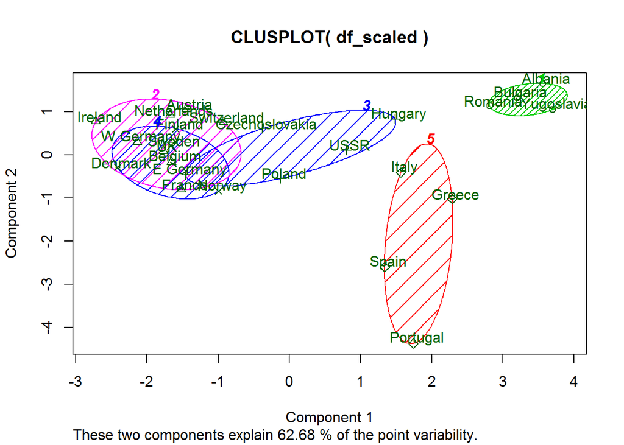

```r
hclust_plot = function(d, method, k)
{
  cluster_obj = cutree(  hclust(d=d, method = method )  ,  k=k  )
  clusplot(df_scaled, cluster_obj, color=TRUE, shade=TRUE, labels=2, lines=0  )
}

hclust_plot(d = dist_obj, method = "ward.D2" , k = 5 )
```

Can we assign some level of statistical confidence to our clusters?

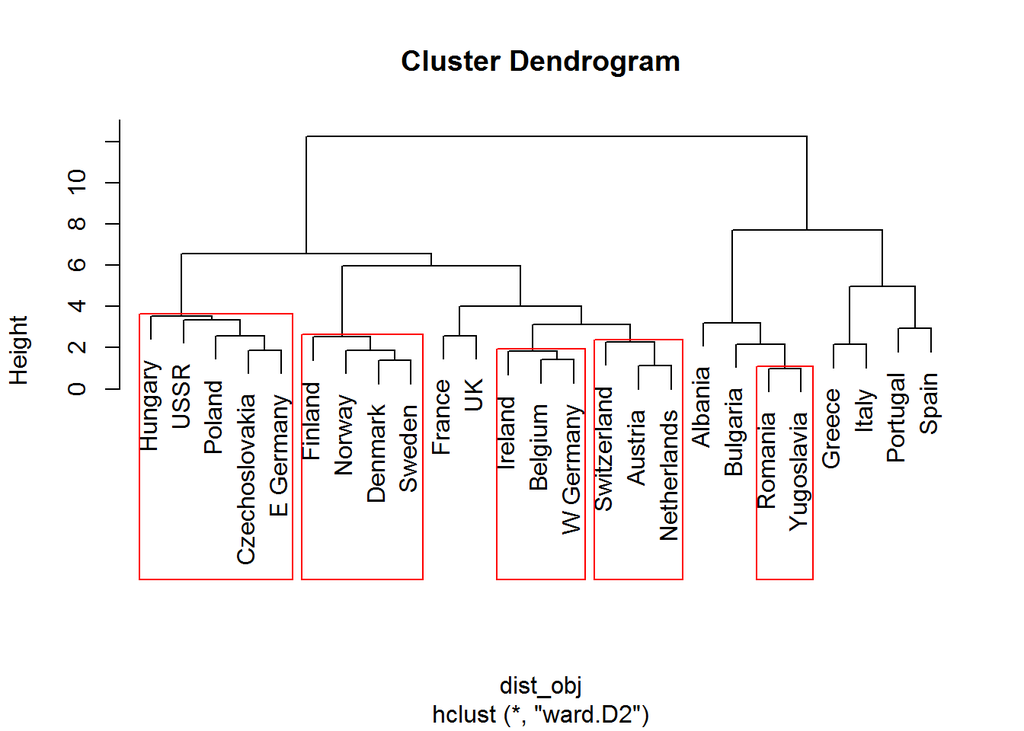

```r
df_scaled_tr = t(data.matrix(df_scaled))

pv_obj = pvclust(df_scaled_tr,   method.hclust="ward.D2", method.dist="euclidean")

plot(hclust(dist_obj, method = "ward.D2" ))
pvrect(pv_obj, alpha = 0.95)
```

The highlighted clusters are significant at a 5% level.

### K-means clustering

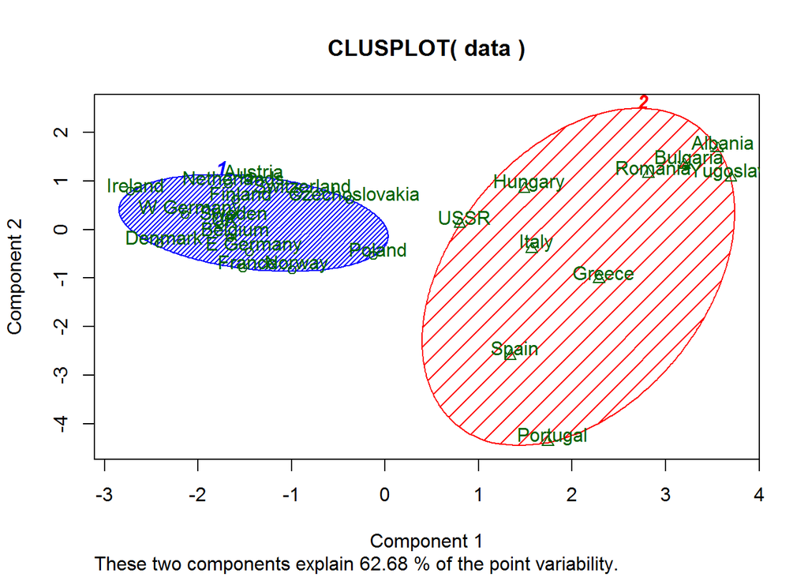

```r
kmeans_plot = function(data, k)
{
  kmeans_obj = kmeans(data, k)
  kmeans_obj$cluster
  clusplot(data , kmeans_obj$cluster, color=TRUE, shade=TRUE, labels=2, lines=0)
}

kmeans_plot(df_scaled, 2)
```

The clusters from K-means clustering are not particularly stable with 5 clusters, but they are with two clusters.

We can add an artificial outlier:

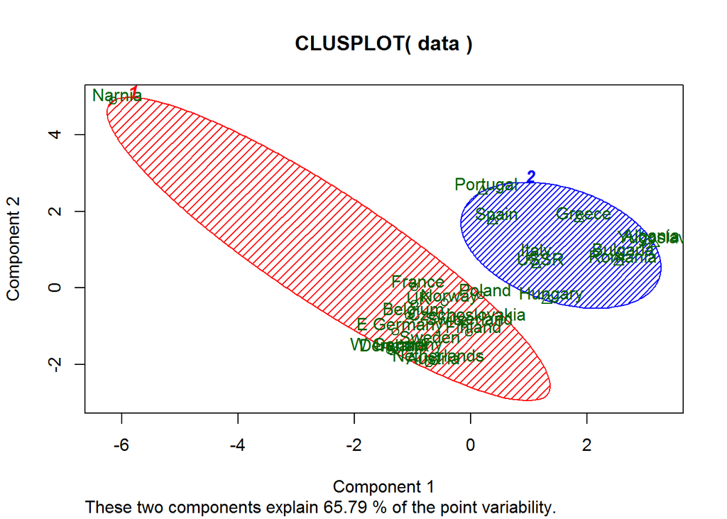

```r
Narnia = c(10,-1,1,-10,1,-1,10,-1,1)
df_w_outlier = scale(rbind(df_scaled, Narnia))
rownames(df_w_outlier)[26] = "Narnia"
kmeans_plot(df_w_outlier, 2)
```

With 2 components, we get pretty close to the correct answer in the presence of an outlier.

*kmeansruns* Will give us a way of choosing the number of clusters:

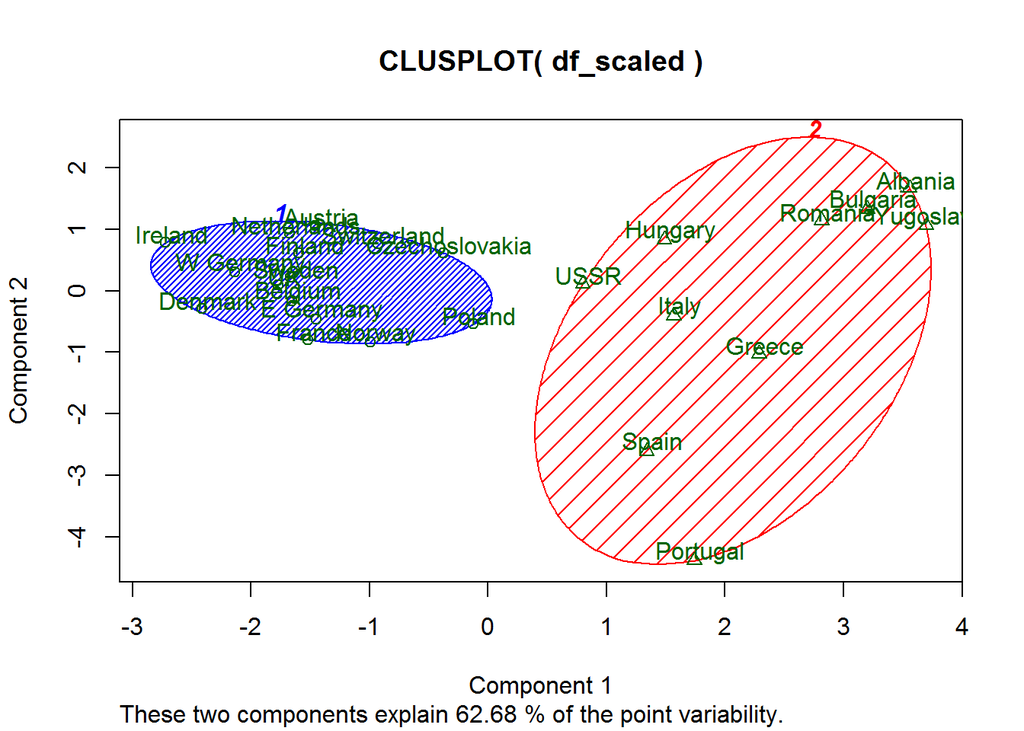

```r
kmr_obj_ch = kmeansruns(df_scaled, criterion="ch")
clusplot(df_scaled , kmr_obj_ch$cluster, color=TRUE, shade=TRUE, labels=2, lines=0)
```

We can use a different criterion in *kmeansruns*

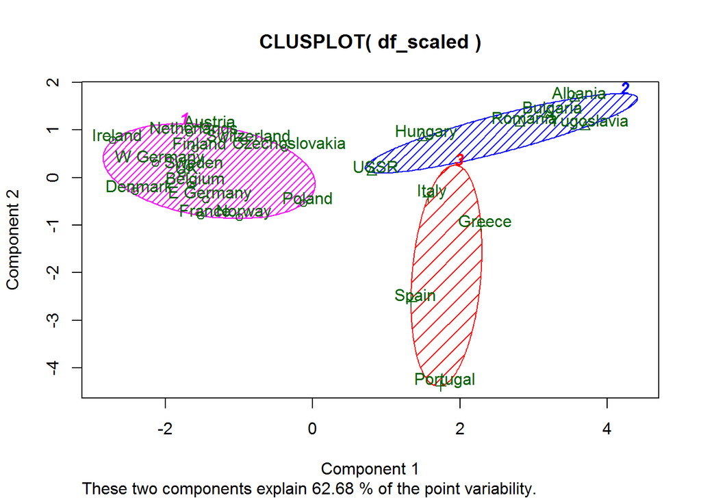

```r
kmr_obj_asw = kmeansruns(df_scaled, criterion="asw")
clusplot(df_scaled , kmr_obj_asw$cluster, color=TRUE, shade=TRUE, labels=2, lines=0)
```

the *asw* criterion stably produces three clusters. We can plot the value of the criterion we are trying to optimise against the number of clusters, K. As we can see, the *asw* criterion is maximized at 3 clusters:

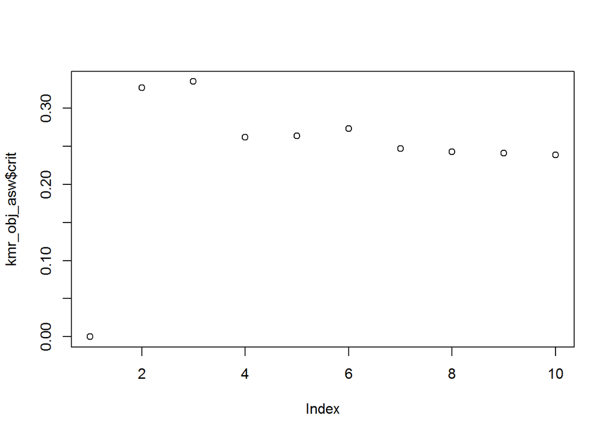

```r
plot(kmr_obj_asw$crit)
```

And for the *ch* criterion:

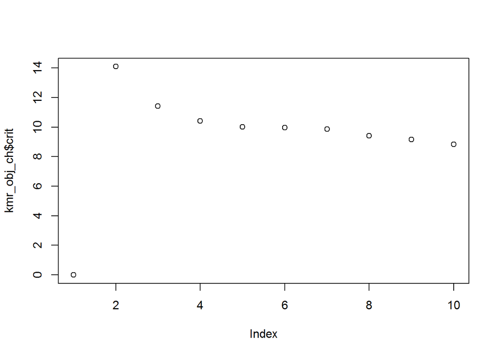

```r
plot(kmr_obj_ch$crit)
```

The *ch* criterion is maximized at 2 clusters.

### Robustness analysis

We can also use clusterboot() from the fpc package to repeatedly resample our data with replacement, run K-means clustering on each bootstrapped sample, and test how often clusters are dissolved in the bootstrapped clusters. This gives us a notion of how “real” the clusters are.

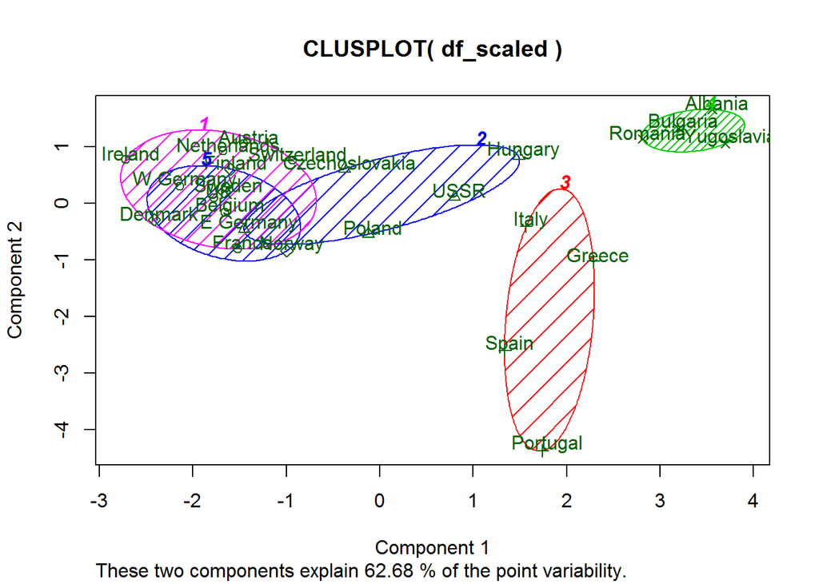

```r
cb_obj = invisible(clusterboot(df_scaled, clustermethod=kmeansCBI, runs=100, iter.max=100, krange=5 ))
clusplot(df_scaled , cb_obj$result$partition, color=TRUE, shade=TRUE, labels=2, lines=0)
```

```r
cb_obj$bootmean
```

[output not shown]

## Mixture models

#### old faithful eruptions

We will examine old faithful eruption times, looking to model them as a mixture model. First consider the waiting times:

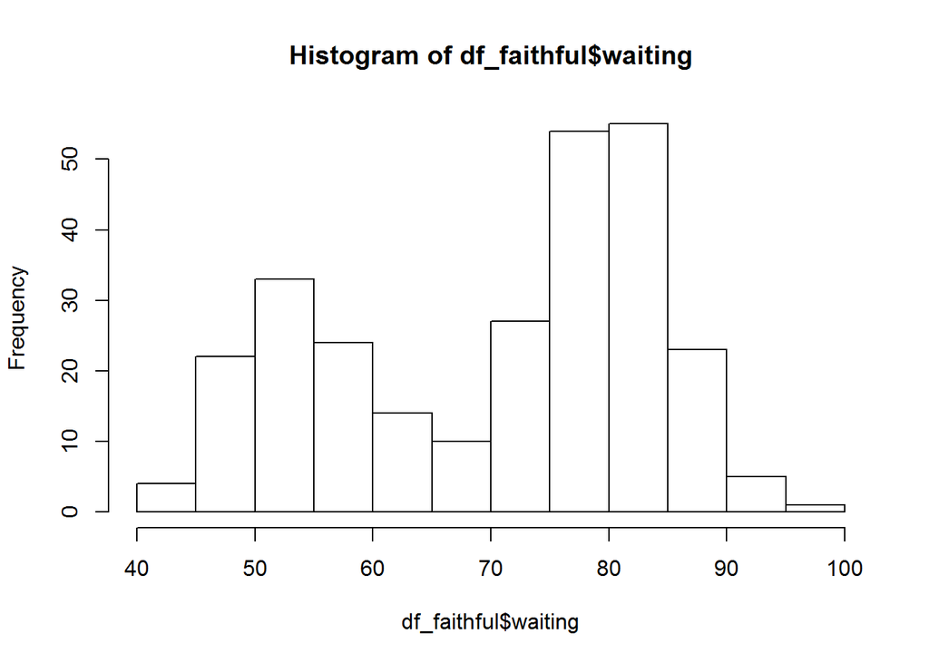

```r
df_faithful = faithful
hist(df_faithful$waiting)
```

And also the duration of the eruptions:

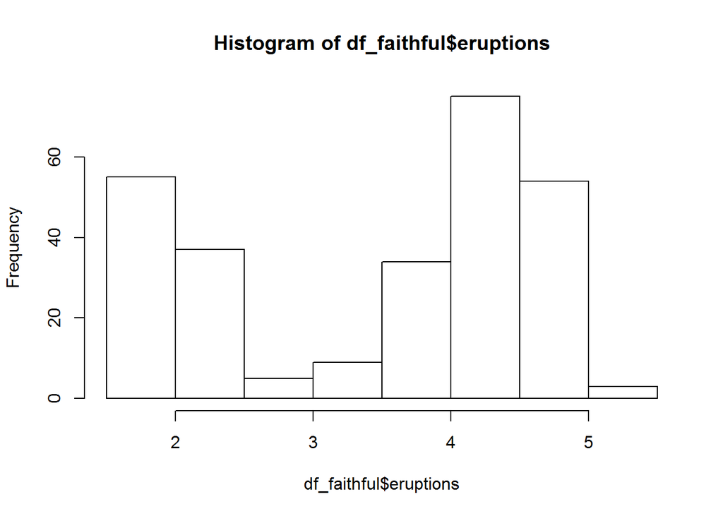

```r
hist(df_faithful$eruptions )
```

Model the waiting times as a mixture of normals:

```r
mix_obj = normalmixEM(df_faithful$waiting)
```

```
## number of iterations= 29
```

```r
summary(mix_obj)
```

```
## summary of normalmixEM object:
##           comp 1    comp 2
## lambda  0.360887  0.639113
## mu     54.614888 80.091089
## sigma   5.871241  5.867718
## loglik at estimate:  -1034.002
```

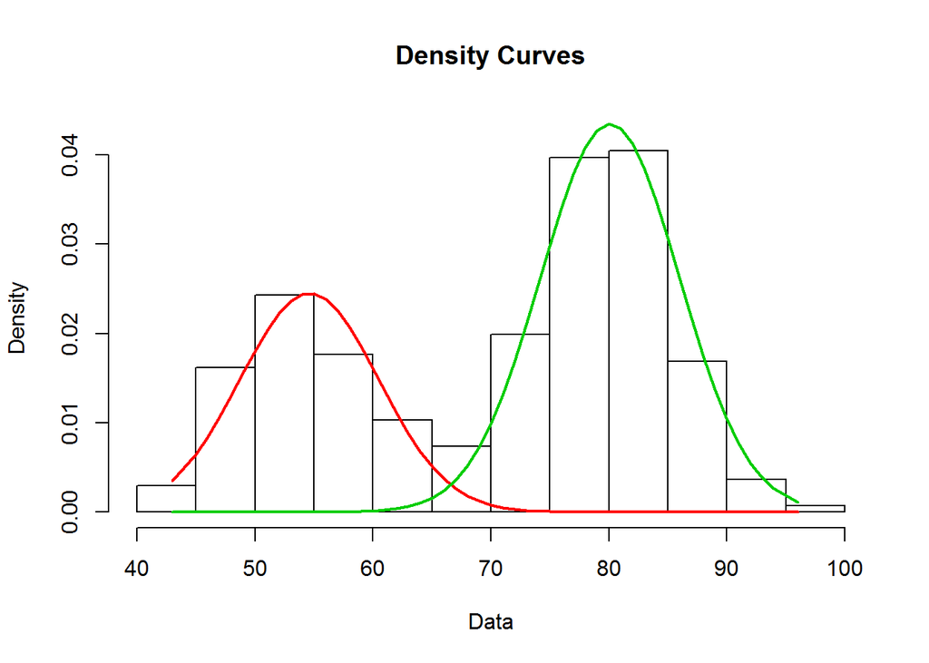

```r
plot(mix_obj, density=TRUE, which=2 )
```

Try a mixture model with the “wrong” number of components:

```r
mix_obj_3 = normalmixEM(df_faithful$waiting, k=3)
```

```
## number of iterations= 434
```

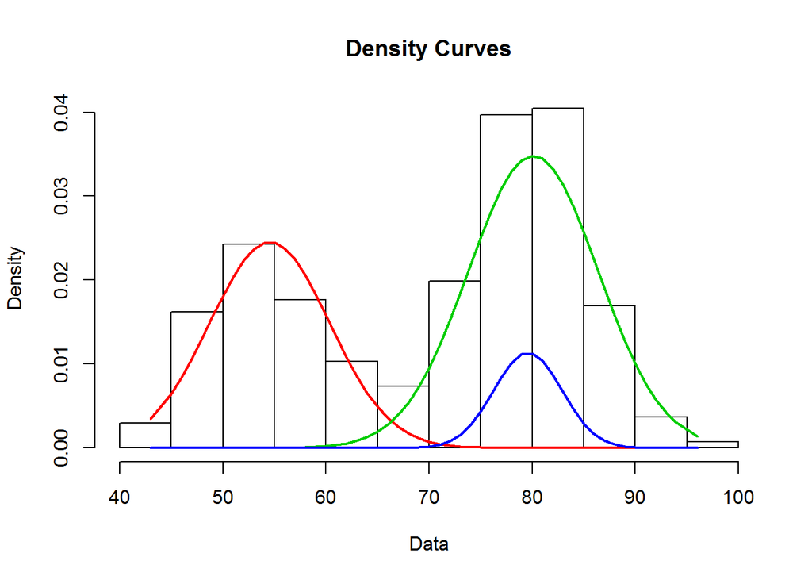

```r
plot(mix_obj_3, density=TRUE, which=2 )
```

We can see that the result is unstable - you get wildly different parameters every time.

### Semiparametric methods

We can use a semiparametric model:

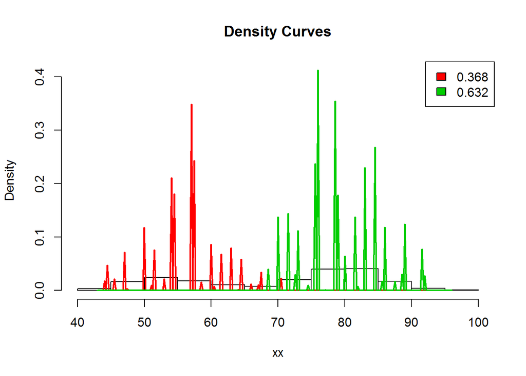

```r
sp_obj = spEMsymloc(df_faithful$waiting, mu0 = 2, bw = 0.01)
plot(sp_obj)
```

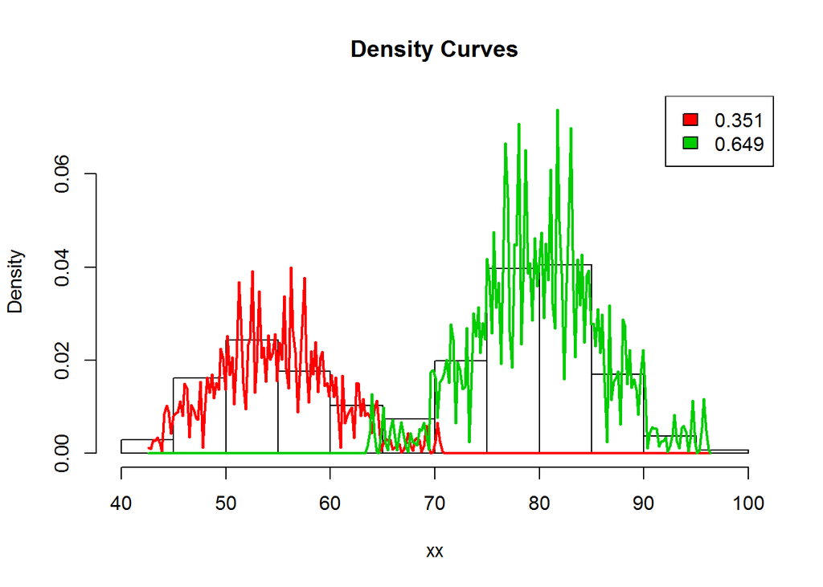

```r
sp_obj = spEMsymloc(df_faithful$waiting, mu0 = 2, bw = 0.1)
plot(sp_obj)
```

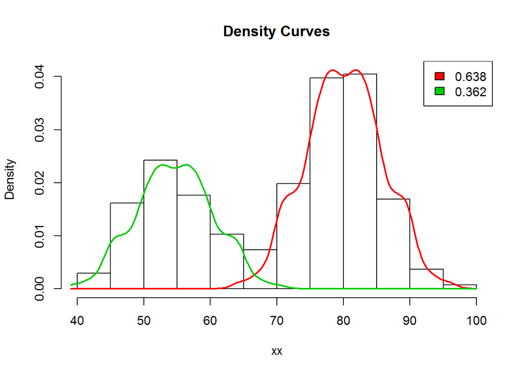

```r
sp_obj = spEMsymloc(df_faithful$waiting, mu0 = 2, bw = 1)
plot(sp_obj)
```

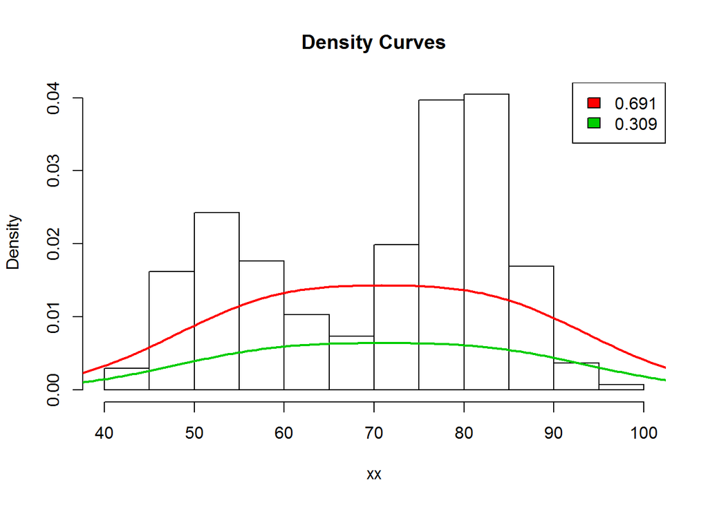

```r
sp_obj = spEMsymloc(df_faithful$waiting, mu0 = 2, bw = 10)
plot(sp_obj)
```

We can test the robustness of a semiparametric model to outliers:

```r
df_faithful_ol = rbind(df_faithful, c(19, 190), c(23, 180) )
```

the semiparamatric model can be vulnerable to outliers with a bad bandwidth parameter

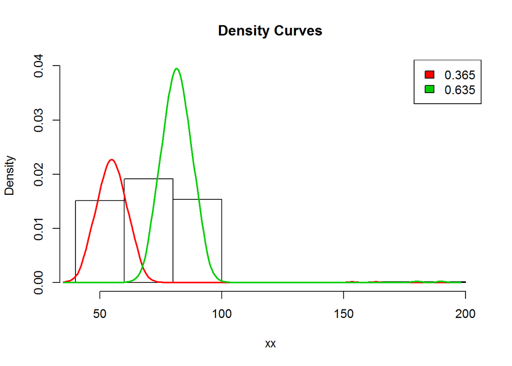

```r
sp_obj_ol = spEMsymloc(df_faithful_ol$waiting, mu0 = 2, bw = 2)
plot(sp_obj_ol)
```

### Multivariate mixture models

Looking at the old faithful data, there are clearly two clusters:

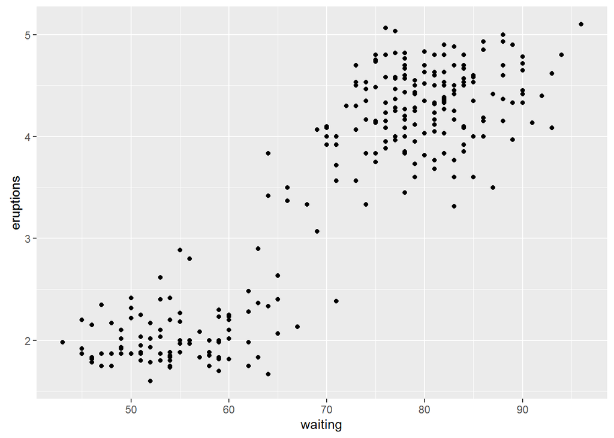

```r
ggplot(data = df_faithful, aes(x = waiting, y = eruptions ) ) + geom_point()
```

We would like to cluster them into two clusters. First we should scale the data.

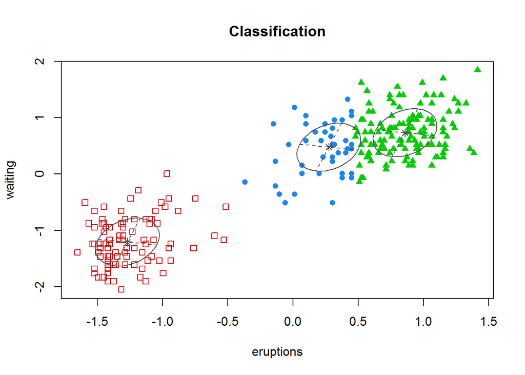

```r
df_fs = scale(df_faithful)
Lust_obj = Mclust(df_fs)
plot(Lust_obj, what = "classification")
```

Try the same thing with the protein consumption data. The issue with this data is the larger number of dimensions makes it hard to understand the resulting clusters - since they are in high-dimensional space.

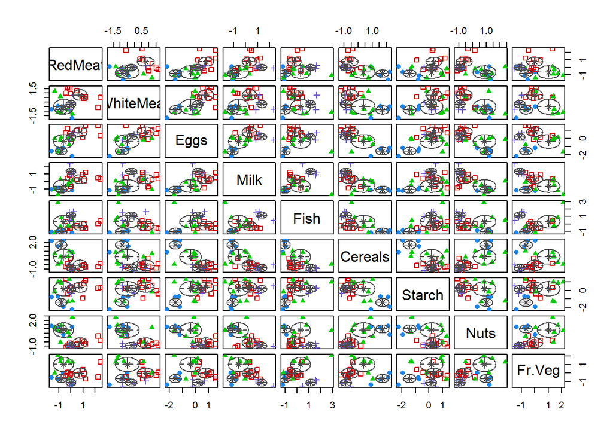

```r
Lust_obj_pr = Mclust(df_scaled)
plot(Lust_obj_pr, what = "classification")
```

clusplot allows us to visualize the clusters from *mclust*:

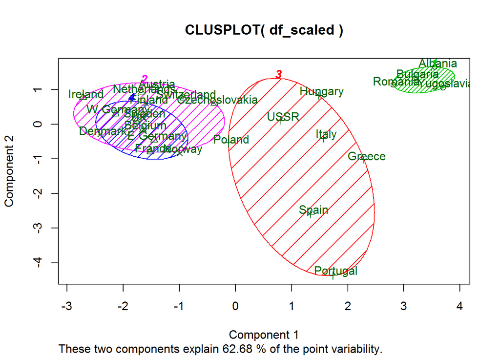

```r
clusplot(df_scaled , Lust_obj_pr$classification, color=TRUE, shade=TRUE, labels=2, lines=0)
```

We can do the same thing with *npEM*:

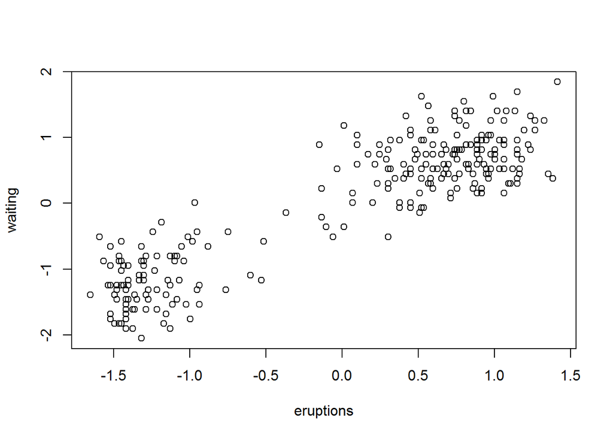

```r
plot(df_fs)
```

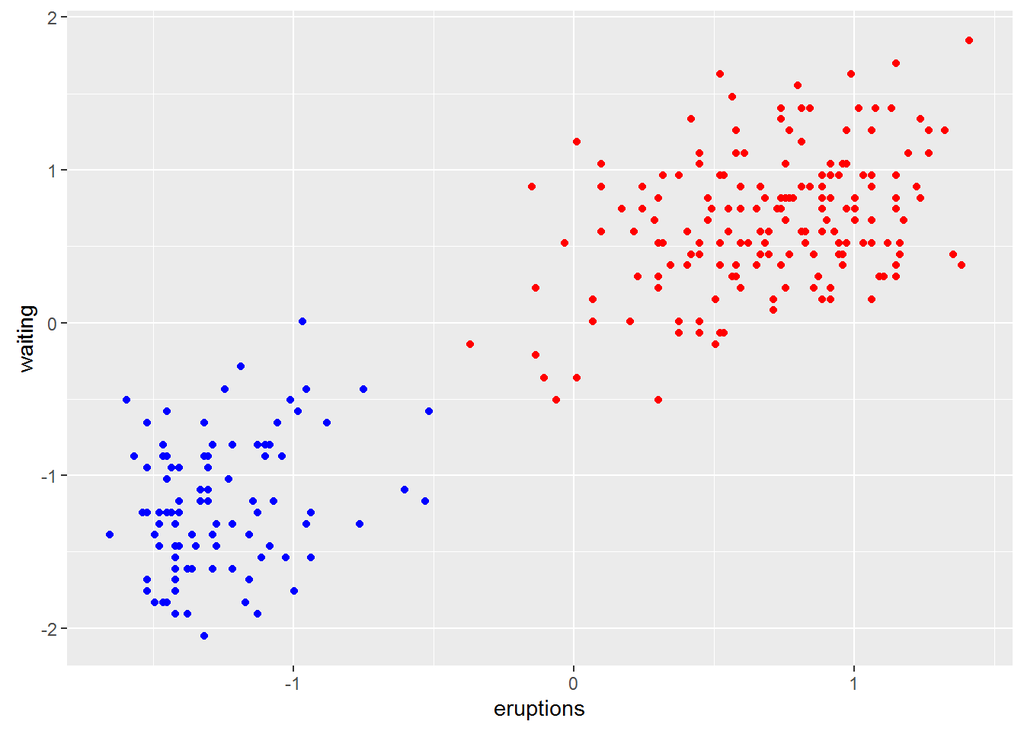

```r
np_obj = npEM(df_fs, mu0 = 2 )
np_obj$posteriors
labels = apply(np_obj$posteriors, 1, which.max)
mypal = colorRampPalette( c( "red", "blue" ) )( 2 )
np_data = cbind( data.frame(df_fs) ,  labels  )
ggplot(data = np_data, aes(x=eruptions, y=waiting)) + geom_point( color = mypal[labels] )
```